# BANA 4080: Introduction to Data Mining with Python

Week 13: Unsupervised Learning

## Welcome to Week 13

- Quick overview of today’s plan:
  - What changes when there’s no target to predict
  - Clustering: finding natural groups with K-Means
  - Choosing K, and turning clusters into segments
  - PCA: compressing many features into a few
  - PCA as a feature engineering step

## 📓 Follow Along in the Notebook

**Week 13 Lecture Notebook**

Open the Lecture notebook in Colab now and follow along as we work through today’s examples on K-Means clustering and PCA.

[figure not shown]

Open In Colab

# Week 12 Recap

## Last Week in 60 Seconds

🔒 Test-set peeking

Every decision made by looking at the test score makes that score **optimistic**

🔁 Cross-validation

**k honest validation scores** from the training set alone, so the test set stays locked away

🎛️ GridSearchCV

Try **every combination** of settings, score each with CV, then refit the best one

🧰 Pipelines

Impute, encode, and scale **inside CV**, so no information leaks from the validation folds

**Tip**

Every model so far learned from a target `y`: a sale price, a default, a diagnosis. Today there is no `y`. We look for structure in `X` alone.

# What is Unsupervised Learning?

## Supervised vs. Unsupervised Learning

**Everything we’ve done so far has been supervised learning:**

**Supervised learning**

- You have a target `y` (labels)
- Goal: **predict** the outcome
- Examples:
  - Predict house prices
  - Classify loan defaults
- Success: RMSE, accuracy, … against the true `y`

**Unsupervised learning**

- No target, only features `X`
- Goal: **discover** structure
- Examples:
  - Find customer segments
  - Compress many correlated features
- Success: does the structure make sense, and is it useful?

## Two Kinds: Rows vs. Columns

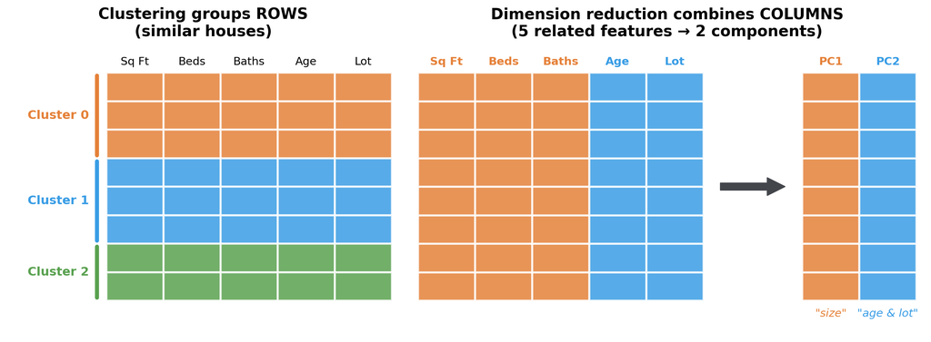

**Important**

**Clustering** groups similar **rows**. **Dimension reduction** combines related **columns**.

## Think-Pair-Share: Which Kind of Problem?

**Discuss with your neighbor.** Is each one clustering, dimension reduction, or supervised learning? Why?

1. **A**: Use customer purchase history to create groups for targeted marketing campaigns
2. **B**: Predict which customers will cancel their subscription next month
3. **C**: Organize 10,000 products into groups of similar items
4. **D**: Predict a house’s price from its square footage and location
5. **E**: Summarize 40 related survey questions with a handful of scores

# Clustering with K-Means

## What is Clustering?

**Clustering** automatically groups similar observations together without being told what the groups should be.

**Real-world applications:**

- **Marketing**: Segment customers by behavior
- **Retail**: Group products by purchase patterns
- **Healthcare**: Identify patient subtypes
- **Fraud detection**: Find unusual transaction patterns
- **Document analysis**: Organize similar articles
- **Image compression**: Group similar pixels

```
graph TD
    A[1000 Customers<br/>Many features] --> B{Clustering<br/>Algorithm}
    B --> C1[Segment 1:<br/>Budget Shoppers]
    B --> C2[Segment 2:<br/>Premium Buyers]
    B --> C3[Segment 3:<br/>Occasional Visitors]

    style A fill:#f0f0f0
    style B fill:#43464B,color:#fff
    style C1 fill:#FF6B6B
    style C2 fill:#4ECDC4
    style C3 fill:#45B7D1
```

## K-Means, Step by Step

[interactive chart not shown]

## Scale Before You Cluster

Same lesson as week 12’s **“Who Are My Neighbors?”** K-Means measures distance, and in raw units $1 counts as much as 1 visit, so the big-number column decides who’s “close.” `StandardScaler` gives every column a fair say.

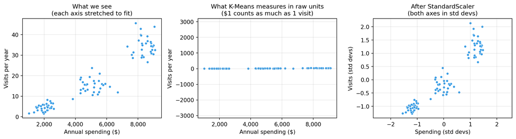

## K-Means in scikit-learn

```python
from sklearn.cluster import KMeans
from sklearn.preprocessing import StandardScaler

customers_scaled = StandardScaler().fit_transform(customers)

kmeans = KMeans(n_clusters=3, n_init=10, random_state=42)
cluster_labels = kmeans.fit_predict(customers_scaled)

customers.assign(cluster=cluster_labels).round(1).sample(4, random_state=42)
```

|  | annual_spending | visits_per_year | cluster |
| --- | --- | --- | --- |
| 40 | 5594.6 | 13.8 | 0 |
| 22 | 2611.3 | 3.8 | 2 |
| 55 | 4488.9 | 13.8 | 0 |
| 70 | 7607.0 | 30.2 | 1 |

**Two settings worth knowing**

- **`n_init=10`**: run K-Means from 10 different starts and keep the one with the lowest inertia (remember Start B?)
- **`random_state=42`**: makes those starts repeatable, so you get the same clusters every time you run it

## How Many Clusters (K)?

K-Means needs K up front. Fit several values of K and score each fit two ways:

**📉 Inertia (elbow method)**

- Total squared distance from each customer to its centroid
- **Lower = tighter clusters**, but it *always* drops as K grows
- Look for the **elbow**: where adding a cluster stops buying much

**📈 Silhouette score**

- For each customer: how close to its own cluster vs. the next-nearest one
- Ranges from −1 to +1; **higher = better separated**
- Look for the **peak**

```python
inertia = KMeans(n_clusters=k, n_init=10, random_state=42).fit(customers_scaled).inertia_
score = silhouette_score(customers_scaled, cluster_labels)
```

## Choosing K

[interactive chart not shown]

## From Clusters to Segments

K-Means hands back **cluster numbers**. **Profile** each cluster (average its features), **name** it in business terms, and it becomes a **segment** you can **act** on.

```python
segment_names = ['Occasional shoppers', 'Regulars', 'Loyal big spenders']

(customers
 .assign(cluster=cluster_labels)
 .groupby('cluster')
 .agg(customers=('annual_spending', 'size'),
      avg_spending=('annual_spending', 'mean'),
      avg_visits=('visits_per_year', 'mean'))
 .sort_values('avg_spending')
 .assign(segment=segment_names)   # names chosen AFTER reading the profile
 .round(1))
```

| cluster | customers | avg_spending | avg_visits | segment |
| --- | --- | --- | --- | --- |
| 2 | 30 | 2008.4 | 4.5 | Occasional shoppers |
| 0 | 30 | 5091.0 | 15.0 | Regulars |
| 1 | 30 | 8428.9 | 34.6 | Loyal big spenders |

## Real Data Is Messy

Same workflow, real customers: **801 households** from a grocery retailer’s Complete Journey data, with **14 features** per household.

**🛒 Behavioral (8)**

Total spending, average basket value, number of trips, unique products, days between trips, recency, discount rate, coupon usage

**👪 Demographic (6)**

Age, income, household size, number of kids, married, homeowner

Scale all 14 features, fit K-Means for K = 2 to 10, and read the same two scores as before.

## Real Data: No Clear Answer

[interactive chart not shown]

- **No elbow:** inertia falls smoothly, with no bend to point at
- **Low silhouette:** about 0.15 at every K (our toy customers scored 0.75 at K = 3). K = 2 is highest, but barely
- **This is normal.** Real customers sit on a spectrum, not in neat boxes

## When the Scores Don’t Decide

The metrics narrow the options. **People** make the call.

**Work with stakeholders**

1. **Try a few K values** that the scores don’t rule out (say 3, 4 and 5)
2. **Profile each one** and name the segments, as we did with the toy customers
3. **Show the options** to the people who will use them
4. **Choose** the K whose segments are clear, actionable, and something the team can actually run campaigns for

> A grocery marketing team that can run four campaigns might pick **K = 4** (budget shoppers, loyal regulars, premium buyers, infrequent visitors), even though K = 2 scores slightly higher.

# PCA: Fewer Columns, Same Information

## The Problem: Too Many Columns

Real datasets keep getting **wider**: hundreds or thousands of columns, many of them telling the same story.

**😩 What wide data costs you**

- **Redundancy:** correlated columns (square feet, bedrooms, bathrooms) repeat each other
- **Overfitting:** more columns, more noise to memorize
- **Speed:** training slows down
- **Seeing it:** you can’t plot 100 dimensions

**🌍 Where it shows up**

- **Healthcare:** 20,000+ genes per patient
- **Images:** thousands of pixels per photo
- **Retail:** hundreds of behaviors per customer
- **Text:** thousands of word counts per document

**Question:** do we really need all of those columns, or can a few new ones carry most of the information?

## Two Ways to Get Fewer Columns

Both start from many correlated columns and end with fewer:

**✂️ Feature selection**

**Keep a subset** of the original columns, e.g. the most important features from week 11. Easy to explain, but every dropped column’s information is gone.

**🧪 Feature extraction (PCA)**

**Build a few new columns**, each a weighted mix of *all* the originals. **PCA** (principal component analysis) builds them so the first keeps as much of the data’s spread as possible, the second keeps the most of what’s left, and so on.

## Finding the Direction of Most Variance

[interactive chart not shown]

## Visualizing PCA in 3D: House Features

Let’s see how PCA works with 3 house features: square feet, bedrooms, and bathrooms.

**Rotate the plot to see how PC1 aligns with the direction of maximum spread!**

[interactive chart not shown]

```
Variance explained by each component:
  PC1: 92.5%
  PC2: 5.6%
  PC3: 2.0%

PC1 captures most variance because sq ft, bedrooms, and bathrooms are all correlated!
```

## PCA on Real Data: Scale First

**Wine:** 178 wines, 13 chemical measurements each, from three cultivars (grape varieties). We’ll use the cultivar only to *check* the results, never to fit PCA.

```python
from sklearn.datasets import load_wine
from sklearn.decomposition import PCA

wine = load_wine(as_frame=True)
X_wine, y_wine = wine.data, wine.target

pca_unscaled = PCA().fit(X_wine)
wine_scaled = StandardScaler().fit_transform(X_wine)
pca = PCA().fit(wine_scaled)

print(f"PC1 share of the variance, unscaled: {pca_unscaled.explained_variance_ratio_[0]:.1%}")
print(f"PC1 share of the variance, scaled:   {pca.explained_variance_ratio_[0]:.1%}")
```

```
PC1 share of the variance, unscaled: 99.8%
PC1 share of the variance, scaled:   36.2%
```

**Unscaled, PC1 is just “proline”**

Proline is measured in the hundreds to over a thousand; most other columns are under 10. PCA chases **variance**, so the biggest-number column wins, the same trap as K-Means. Always scale first.

## How Many Components?

[interactive chart not shown]

## What Does PC1 Mean?

Each component is a weighted mix of the original columns. Those weights are its **loadings**.

```python
pc1_loadings = pd.Series(pca.components_[0], index=X_wine.columns).sort_values()
```

[interactive chart not shown]

## 13 Columns, One Picture

```python
wine_2d = PCA(n_components=2).fit_transform(wine_scaled)
```

[interactive chart not shown]

## PCA in a Pipeline

PCA can also feed a model. Put it **inside** the pipeline so it’s refit on each fold’s training part (week 12).

```python
from sklearn.model_selection import train_test_split, cross_val_score
from sklearn.pipeline import Pipeline
from sklearn.linear_model import LogisticRegression

X_train, X_test, y_train, y_test = train_test_split(
    X_wine, y_wine, test_size=0.2, stratify=y_wine, random_state=42)

all_13 = Pipeline([('scale', StandardScaler()), ('model', LogisticRegression(max_iter=1000))])
pcs_2 = Pipeline([('scale', StandardScaler()), ('pca', PCA(n_components=2)),
                  ('model', LogisticRegression(max_iter=1000))])

for name, pipe in [('All 13 columns', all_13), ('2 PCA components', pcs_2)]:
    print(f"{name:>16}: 5-fold CV accuracy {cross_val_score(pipe, X_train, y_train, cv=5).mean():.3f}")
```

```
  All 13 columns: 5-fold CV accuracy 0.993
2 PCA components: 5-fold CV accuracy 0.979
```

# Looking Forward

## Key Takeaways

- **Unsupervised learning**: find structure in `X` when there is no `y`
- **Clustering** groups similar **rows**; K-Means alternates *assign* and *move* until nothing changes
- **Choosing K** takes judgment: the elbow and silhouette inform it, and the business decides it
- **Clusters become segments** once you profile them and give them names
- **PCA** combines correlated **columns** into a few uncorrelated components
- **Always scale first**: both K-Means and PCA are driven by distances and variances

## When to Use Which Method

```
graph TD
    Start[I have unlabeled data] --> Q1{What's my goal?}

    Q1 -->|Find groups<br/>of similar rows| C[Clustering]
    Q1 -->|Fewer, uncorrelated<br/>columns| D[Dimension reduction]
    Q1 -->|Both| Both[PCA, then cluster<br/>on the components]

    C --> C1[K-Means:<br/>customer segments<br/>product groups]
    D --> D1[PCA:<br/>visualization<br/>model inputs]
    Both --> B1[Thursday's Lab,<br/>Challenge 4]

    style Start fill:#f0f0f0
    style Q1 fill:#43464B,color:#fff
    style C fill:#4ECDC4
    style D fill:#FF6B6B
    style Both fill:#45B7D1
```

## More in Your Readings

🌳 Hierarchical clustering

Builds a tree of nested clusters, so you can pick K *after* seeing the structure

🔵 DBSCAN

Finds clusters of any shape by density, and flags outliers that belong to no cluster

⚠️ When K-Means struggles

Non-spherical clusters, very unequal sizes, and outliers, with what to try instead

🧮 How PCA works under the hood

The covariance matrix and eigenvectors behind each component, plus PCA’s cousins

## Thursday’s Lab

**This Week’s Lab Preview**

In Thursday’s lab, you’ll get hands-on practice with:

- Walking through K-Means and PCA on today’s customer and wine data
- Segmenting the Ames housing market with K-Means
- Using PCA to compress 30 tumor measurements, then feeding the components to a classifier
- Clustering on PCA components, with no labels at all

**Homework**

Thursday’s lab will lead into this week’s homework assignment.

## Any Final Questions?

- About clustering and choosing K?
- About PCA and how many components to keep?
- About when to use which method?
- About Thursday’s lab?

**See you Thursday for hands-on clustering and PCA!**